G34-gliomas project [[source](https://github.com/fungenomics/G34-gliomas)]

# 01 - Bulk RNAseq

22 November, 2021

# 1 Configuration

Configuration of project directory & analysis outputs:

**Show full config**

```r
library(here)

# Set up outputs
message("Document index: ", doc_id)
```

```
## Document index: 01
```

```r
# Specify where to save outputs
out        <- here(subdir, "output", doc_id); dir.create(out, recursive = TRUE)
figout     <- here(subdir, "figures", doc_id, "/"); dir.create(figout, recursive = TRUE)
cache      <- paste0("~/tmp/", basename(here()), "/", subdir, "/", doc_id, "/")

message("Cache: ", cache)
```

```
## Cache: ~/tmp/G34-gliomas/bulk_transcriptome_epigenome/01/
```

```r
source(here("include/rr_helpers.R")) # source helper functions prefixed by rr_
source(here("include/style.R"))      # source custom palettes/themes
```

The root directory of this project is:

```
## /lustre03/project/6004736/sjessa/from_beluga/HGG-G34/G34-gliomas
```

Outputs and figures will be saved at these paths, relative to project root:

```
## G34-gliomas/bulk_transcriptome_epigenome/output/01
```

```
## G34-gliomas/bulk_transcriptome_epigenome/figures/01//
```

Setting a random seed:

```r
set.seed(100)
```

# 2 Overview

Here we perform basic RNAseq analysis for G34R/V mutant high-grade gliomas.

This document:

- loads metadata for bulk RNAseq of G34R/V mutant tumors as well as tumors of other comparator groups
- loads metadata for bulk RNAseq of tumor-derived cell lines
- prepares the inputs for our in-house bulk RNAseq pipeline (code not included in this repository)
- generates basic plots of gene expression levels

More complex downstream analysis is performed in subsequent documents.

# 3 Libraries

```r
# General
library(tidyr)
library(readr)
library(dplyr)
library(magrittr)
library(glue)
library(purrr)

# For plotting
library(ggplot2)
library(scales)
library(ggrepel)
ggplot2::theme_set(theme_min(base_size = 13))

# Custom
source(here::here(subdir, "analysis/functions.R"))
```

# 4 Analysis

## 4.1 Prepare inputs for RNAseq pipeline - patient tumors

Load sample metadata:

```r
bulk_samples <- readxl::read_xlsx(
  here::here(subdir, "data/2020-02-25_bulkRNAseq_metadata.xlsx")) %>%
  mutate(G34_batch = ifelse(is.na(G34_batch), "Old", G34_batch))

# Count number of samples per group
table(bulk_samples$Group)
```

```
##
##             HGG-G34R/V     HGG-H3.3-K27M-pons HGG-H3.3-K27M-thalamic
##                     18                      8                      5
##                HGG-IDH                 HGG-WT        PNET-HGNET-BCOR
##                     10                      9                      5
```

Next, we prepare the inputs for the RNAseq. For each comparison (i.e. differential gene expression), we need two files:

- `info.samples.tsv` - describing the membership of each sample to each group
- `info.groups.tsv` - describing the two groups in the comparison

We perform differential gene expression analysis between G34 tumors and each other “comparator” group:

```r
# Get the tumor groups (other than G34R/V)
(groups <- unique(bulk_samples$Group) %>% tail(5))
```

```
## [1] "HGG-H3.3-K27M-pons"     "HGG-H3.3-K27M-thalamic" "HGG-IDH"
## [4] "HGG-WT"                 "PNET-HGNET-BCOR"
```

```r
# Generate inputs for each group
for (group in groups) {

  # Create a name describing the comparison
  comp <- paste0(gsub("/", ".", "HGG-G34R/V"), "_vs_", gsub("/", ".", group))
  dir.create(file.path(out, comp), showWarnings = FALSE)

  # Create the info.samples.tsv, which needs three columns: ID (path
  # to the alignment and counts in our in-house pipeline), Nickname (short sample name), and Group
  bulk_samples %>%
    select(ID, Nickname = Sample, Group, Batch = G34_batch) %>%
    filter(Group %in% c("HGG-G34R/V", group)) %>%
    write_tsv(file.path(out, comp, "info.samples.tsv"))

  # Create the info.groups.tsv
  data.frame(Group = c("HGG-G34R/V", group),
             Label = c("HGG-G34R/V", group),
             Order = c(2, 1),
             stringsAsFactors = FALSE) %>%
    write_tsv(file.path(out, comp, "info.groups.tsv"))

}
```

We will also need one version with all samples together, since normalization is dataset-dependent, and we will compare expression levels across groups.

```r
# As above, but without batch correction since we won't be doing differential
# expression analysis here
dir.create(file.path(out, "All_tumor_samples"), showWarnings = FALSE)

bulk_samples %>%
  select(ID, Nickname = IC_Sample, Group) %>%
  write_tsv(file.path(out, "All_tumor_samples", "info.samples.tsv"))

data.frame(Group = unique(bulk_samples$Group),
           Label = unique(bulk_samples$Group),
           Order = seq_along(unique(bulk_samples$Group)),
           stringsAsFactors = FALSE) %>%
  write_tsv(file.path(out, "All_tumor_samples", "info.groups.tsv"))
```

Finally, we peform one analysis among G34R/V tumors, between PDGFRA mutants vs. WT:

```r
# Exactly as above
dir.create(file.path(out, "G34RV_by_PDGFRA"), showWarnings = FALSE)

bulk_samples %>%
  filter(Group == "HGG-G34R/V") %>%
  select(ID, Nickname = Sample, Group = Genotype_PDGFRA, G34_batch, Genotype_G34) %>%
  write_tsv(file.path(out, "G34RV_by_PDGFRA", "info.samples.tsv"))

data.frame(Group = c("Mutant", "WT"),
           Label = c("Mutant", "WT"),
           Order = c(2, 1),
           stringsAsFactors = FALSE) %>%
  write_tsv(file.path(out, "G34RV_by_PDGFRA", "info.groups.tsv"))
```

The in-house RNAseq pipeline is then run on these inputs, generating normalized expression counts as well as the output of differential gene expression analysis using DESeq2.

## 4.2 Prepare inputs for RNAseq pipeline - cell lines

Load sample metadata for parental cell lines:

```r
cl_samples <- readxl::read_xlsx(here::here(subdir, "data/2020-07-23_cellline_parental_metadata.xlsx"))
```

## 4.3 Plot gene expression: tumours

Prepare colour palettes for visualization:

```r
palette_groups <- c(
  "G34R/V"            = "cyan4",
  "G34R/V-PDGFRA mut" = "#26A27D",
  "G34R/V-PDGFRA WT"  = "#145448",
  "K27M-pons"         = "gold1",
  "K27M-thal"         = "goldenrod3",
  "IDH"               = "#883067",
  "WT"                = "navy",
  "HGNET-BCOR"        = "lavender")

palette_pdgfra <- c("Mutant" = "red",
                    "WT"     = "gray70")

palette_g34    <- c("G34R"   = "#3d8a71",
                    "G34V"   = "#6bbfad")
```

Load normalized counts for genes of interest from the pipeline run:

```r
pipeline_path <- "../../../level3/2020-01_G34_submission1_add_samples/"

# Define genes which we'll plot in this document
genes_of_interest <- c("GSX2", "DLX1", "DLX2", "PDGFRA", "MOXD1", "EOMES", "NEUROD2")

# Load counts and convert to tidy format - see function specification
# in functions.R
counts_subset <- extract_pipeline_counts(path = file.path(pipeline_path,
                                                          "All_tumor_samples/counts/Ensembl.ensGene.exon.norm.tsv.gz"),
                                         goi = genes_of_interest) %>%
  left_join(bulk_samples, by = c("sample" = "Sample"))
# Tidy up and simplify the names of the tumor groups
counts_subset <- counts_subset %>%
  mutate(Group2 = recode(Group,
                         "HGG-G34R/V" = "G34R/V",
                         "HGG-H3.3-K27M-pons" = "K27M-pons",
                         "HGG-H3.3-K27M-thalamic" = "K27M-thal",
                         "HGG-IDH" = "IDH",
                         "HGG-WT" = "WT",
                         "PNET-HGNET-BCOR" = "HGNET-BCOR")) %>%
  mutate(Group3 = case_when(
    Genotype_PDGFRA == "Mutant" ~ paste0(Group2, "-", "PDGFRA mut"),
    Genotype_PDGFRA == "WT" ~ paste0(Group2, "-", "PDGFRA WT"),
    TRUE ~ Group2
  )) %>%
  mutate(Group3 = factor(Group3, levels = c(c("G34R/V-PDGFRA mut",
                                              "G34R/V-PDGFRA WT",
                                              "IDH",
                                              "K27M-pons",
                                              "K27M-thal",
                                              "WT",
                                              "HGNET-BCOR"))))
```

### 4.3.1 PDGFRA

Plot PDGFRA expression levels across tumor groups:

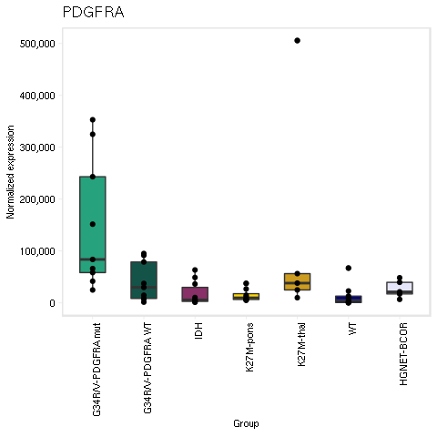

```r
# Plot PDGFRA expression and save source data alongside
counts_subset %>%
  filter(gene_symbol == "PDGFRA") %>%
  select(sample, group = Group3, Pdgfra_normalized_expression = gene_expression) %>%
  rr_ggplot(aes(x = group, y = Pdgfra_normalized_expression), plot_num = 1) +
  geom_boxplot(aes(fill = group), width = 0.5) +
  scale_fill_manual(values = palette_groups) +
  geom_point() +
  scale_y_continuous(labels = comma) +
  rotateX() +
  ylab("Normalized expression") + xlab("Group") + ggtitle("PDGFRA") +
  noLegend()
```

<sub>[figure/source data @ *G34-gliomas/bulk_transcriptome_epigenome/figures/01//bulk_RNAseq_PDGFRA_expression…*]</sub>

### 4.3.2 Lineage specific TFs

Plot expression levels of certain interneuron and excitatory neuron lineage specific TFs/genes:

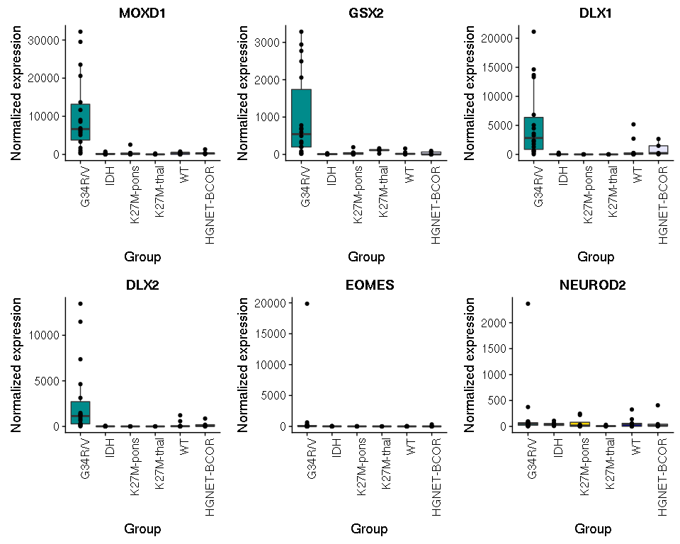

```r
# Subset data to save as source data
boxplot_genes <- c("MOXD1", "GSX2", "DLX1", "DLX2", "EOMES", "NEUROD2")

counts_subset_boxplot <- counts_subset %>%
  filter(gene_symbol %in% boxplot_genes) %>%
  select(sample, gene_symbol, group = Group2, Normalized_expression = gene_expression)

# Helper function
boxplot_tumor_groups <- function(gene) {

  p1 <- counts_subset_boxplot %>%
    # Specify the order of tumour groups along the x-axis
    mutate(group = factor(group, levels = c(c("G34R/V", "IDH", "K27M-pons", "K27M-thal", "WT", "HGNET-BCOR")))) %>%
    filter(gene_symbol == gene) %>%
    ggplot(aes(x = group, y = Normalized_expression)) +
    geom_boxplot(aes(fill = group), outlier.shape = NA) +
    geom_point(size = 1.5) +
    scale_fill_manual(values = palette_groups) +
    rotateX() +
    ylab("Normalized expression") + xlab("Group") + ggtitle(gene) +
    noLegend()

  p1

}

# Loop over genes, generate boxplot, and assemble into one figure
boxplots <- map(boxplot_genes, boxplot_tumor_groups)
rr_plot_grid(df = counts_subset_boxplot, plot_num = 1, plotlist = boxplots, ncol = 3)
```

<sub>[figure/source data @ *G34-gliomas/bulk_transcriptome_epigenome/figures/01//bulk_RNAseq_TF_expression…*]</sub>

## 4.4 PDGFRA vs. GSX2 correlation in tumours & cell lines

### 4.4.1 G34 mutants

Here we’ll examine the correlation between PDGFRA and GSX2 expression in bulk RNAseq data for human tumours and patient-derived cell lines.

```r
goi <- c("GSX2", "PDGFRA")

cor_df <- extract_pipeline_counts(file.path(pipeline_path, "G34RV_and_parental_cell_lines/counts/Ensembl.ensGene.exon.norm.tsv.gz"),
                                  goi)  %>%
  left_join(bind_rows(bulk_samples, cl_samples), by = c("sample" = "Sample")) %>%
  mutate(Group2 = paste0(Source, " - ", Genotype_PDGFRA)) %>%
  select(sample, Group2, gene_symbol, gene_expression, Source) %>%
  spread(gene_symbol, gene_expression)
# Linear model for G34
m <- lm(PDGFRA ~ GSX2, cor_df)

# Check the model
summary(m)
```

```
##
## Call:
## lm(formula = PDGFRA ~ GSX2, data = cor_df)
##
## Residuals:
##     Min      1Q  Median      3Q     Max
## -154320  -25556  -15324   32991  236256
##
## Coefficients:
##             Estimate Std. Error t value Pr(>|t|)
## (Intercept) 26239.18   21681.00   1.210 0.239031
## GSX2           63.00      13.91   4.529 0.000166 ***
## ---
## Signif. codes:  0 '***' 0.001 '**' 0.01 '*' 0.05 '.' 0.1 ' ' 1
##
## Residual standard error: 80730 on 22 degrees of freedom
## Multiple R-squared:  0.4825, Adjusted R-squared:  0.459
## F-statistic: 20.51 on 1 and 22 DF,  p-value: 0.0001658
```

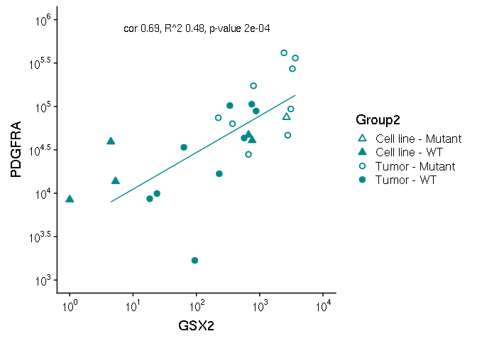

```r
cor <- cor_df %>% select(PDGFRA, GSX2) %>% cor() %>% .[2,1] %>% round(2)
rsq <- round(summary(m)$r.squared, 2)
pv  <- round(summary(m)$coefficients[2,4], 4)

# Generate the basic plot
p1 <- cor_df %>%
  # To avoid errors on log-scale, add a small pseudocount for samples with no Gsx2 expression
  mutate(GSX2 = ifelse(GSX2 == 0, 1, GSX2)) %>%
  rr_ggplot(aes(x = GSX2, y = PDGFRA), plot_num = 1) +
  geom_point(aes(shape = Group2), size = 2, stroke = 1, colour = "cyan4", fill = "cyan4") +
  # Set the shape to be able to distinguish sample groups
  scale_shape_manual(values = c("Tumor - Mutant"     = "circle open",
                                "Tumor - WT"         = "circle filled",
                                "Cell line - Mutant" = "triangle open",
                                "Cell line - WT"     = "triangle filled")) +
  geom_smooth(data = cor_df, method = "lm", se = FALSE, colour = "cyan4", alpha = 0.5, size = 0.5) +
  # Add the stats
  annotate(geom = "text", label = glue("cor {cor}, R^2 {rsq}, p-value {pv}"), x = 10^2, y = 10^5.9) +
  # Log-transform the scale
  scale_x_log10(
    breaks = scales::trans_breaks("log10", function(x) 10^x),
    labels = scales::trans_format("log10", scales::math_format(10^.x)),
    limits = c(1, 10^4)) +
  scale_y_log10(
    breaks = scales::trans_breaks("log10", function(x) 10^x),
    labels = scales::trans_format("log10", scales::math_format(10^.x)),
    limits = c(1, 10^6)) +
  # Zoom into the area of the plot where data is contained
  coord_cartesian(ylim = c(10^3, 10^6))

p1
```

<sub>[figure/source data @ *G34-gliomas/bulk_transcriptome_epigenome/figures/01//gsx2_pdgfra_correlation…*]</sub>

### 4.4.2 Non-G34

Repeat this computation for non-G34 samples, as a comparator.

```r
cor_df_non_g34 <- counts_subset %>%
  mutate(Group2 = recode(Group2, "K27M-pons" = "K27M", "K27M-thal" = "K27M")) %>%
  filter(gene_symbol %in% c("GSX2", "PDGFRA")) %>%
  filter(Group2 != "G34R/V" & Source != "Cell line") %>%
  select(sample, Group2, Source, gene_symbol, gene_expression) %>%
  spread(gene_symbol, gene_expression)

# Linear model for non-G34
m2 <- lm(PDGFRA ~ GSX2, cor_df_non_g34)
summary(m2)
```

```
##
## Call:
## lm(formula = PDGFRA ~ GSX2, data = cor_df_non_g34)
##
## Residuals:
##     Min      1Q  Median      3Q     Max
## -102237  -16944   -6647    4753  386929
##
## Coefficients:
##             Estimate Std. Error t value Pr(>|t|)
## (Intercept)   4953.5    15358.1   0.323   0.7490
## GSX2           699.6      237.5   2.945   0.0057 **
## ---
## Signif. codes:  0 '***' 0.001 '**' 0.01 '*' 0.05 '.' 0.1 ' ' 1
##
## Residual standard error: 74700 on 35 degrees of freedom
## Multiple R-squared:  0.1986, Adjusted R-squared:  0.1757
## F-statistic: 8.676 on 1 and 35 DF,  p-value: 0.0057
```

```r
# R-squared
round(summary(m2)$r.squared, 2)
```

```
## [1] 0.2
```

```r
# p-value
round(summary(m2)$coefficients[2,4], 3)
```

```
## [1] 0.006
```

```r
# Correlation value
sqrt(summary(m2)$r.squared)
```

```
## [1] 0.4456931
```

Let’s also perform the calculation per-group:

```r
map_dfr(unique(cor_df_non_g34$Group2), function(grp) {

  m <- lm(PDGFRA ~ GSX2, cor_df_non_g34 %>% filter(Group2 == grp))
  data.frame("Group"   = grp,
             "R2"      = round(summary(m)$r.squared, 2),
             "p-value" = round(summary(m)$coefficients[2,4], 3),
             "Correlation" = sqrt(summary(m)$r.squared))
}
)
```

| Group | R2 | p.value | Correlation |
| --- | --- | --- | --- |
| HGNET-BCOR | 0.35 | 0.297 | 0.5881594 |
| WT | 0.08 | 0.457 | 0.2853009 |
| IDH | 0.01 | 0.758 | 0.1119512 |
| K27M | 0.26 | 0.077 | 0.5066390 |

## 4.5 Extract differential gene expression analysis

```r
read.table(file.path(pipeline_path, "HGG-G34R.V_vs_HGG-IDH_batch_covariate/diff/Ensembl.ensGene.exon/HGG-IDHvsHGG-G34R.V.tsv"), header = T, sep = "\t", check.names = FALSE) %>%
  filter(padj < 0.01 & baseMean > 100 & abs(log2FoldChange) > 2) %>%
  arrange(desc(log2FoldChange)) %T>%
  rr_write_tsv(path = glue("{out}/DGE_HGG-IDHvsHGG-G34R.V_padj<0.01_baseMean>100_absLFC>2.tsv"),
               desc = "Differentially expressed genes for G34R/V vs IDH patient tumors, filtered to have adjusted p-val <0.01, expression baseMean >100, and absolute log2 fold change >2")
```

```
## ...writing description of DGE_HGG-IDHvsHGG-G34R.V_padj<0.01_baseMean>100_absLFC>2.tsv to G34-gliomas/bulk_transcriptome_epigenome/output/01/DGE_HGG-IDHvsHGG-G34R.V_padj<0.01_baseMean>100_absLFC>2.desc
```

| ID | baseMean | log2FoldChange | lfcSE | stat | pvalue | padj |
| --- | --- | --- | --- | --- | --- | --- |
| ENSG00000230386:RP13-157F18.2 | 124.3063 | 9.036575 | 1.9208618 | 4.704438 | 2.545666e-06 | 2.551452e-04 |
| ENSG00000237735:AP000473.6 | 166.9447 | 8.458577 | 1.0360071 | 8.164593 | 3.225195e-16 | 2.702391e-12 |
| ENSG00000095777:MYO3A | 2005.8312 | 7.670394 | 0.9619065 | 7.974157 | 1.534238e-15 | 9.182416e-12 |
| ENSG00000079689:SCGN | 639.2007 | 7.338952 | 1.3227093 | 5.548424 | 2.882554e-08 | 8.848290e-06 |
| ENSG00000185686:PRAME | 429.7103 | 7.149183 | 1.2123048 | 5.897183 | 3.697593e-09 | 1.702315e-06 |
| ENSG00000124253:PCK1 | 496.9496 | 6.990020 | 0.7635237 | 9.154948 | 5.438390e-20 | 1.139207e-15 |
| ENSG00000197320:AC060834.2 | 191.5382 | 6.989506 | 1.2537353 | 5.574946 | 2.476070e-08 | 7.979613e-06 |
| ENSG00000115844:DLX2 | 2036.7102 | 6.796860 | 0.8194817 | 8.294096 | 1.094139e-16 | 1.145974e-12 |
| ENSG00000144355:DLX1 | 3996.0621 | 6.626103 | 0.7773955 | 8.523465 | 1.548499e-17 | 2.162478e-13 |
| ENSG00000229108:AC005550.4 | 142.7989 | 6.545081 | 1.2744474 | 5.135623 | 2.812107e-07 | 5.151903e-05 |

[output cut: 448 more lines]

# 5 Reproducibility

This document was last rendered on:

```
## 2021-11-22 16:00:13
```

The git repository and last commit:

```
## Local:    master /lustre03/project/6004736/sjessa/from_beluga/HGG-G34/G34-gliomas
## Remote:   master @ origin (git@github.com:fungenomics/G34-gliomas.git)
## Head:     [906cd43] 2021-11-22: Merge branch 'master' of github.com:fungenomics/G34-gliomas
```

The random seed was set with `set.seed(100)`

A project of the Kleinman Lab at McGill University, using the [rr](https://github.com/sjessa/rr/) reproducible research template.  
[home](https://functionalgenomics.ca/) [GitHub](https://github.com/fungenomics/)